# Visualization Guide for cellGeometry

Zaoqu Liu, Myles Lewis

2026-02-03

# 1 Introduction

This vignette provides a comprehensive guide to the visualization functions in **cellGeometry**. Effective visualization is crucial for:

- Quality control of gene signatures
- Identifying problematic cell types
- Interpreting deconvolution results
- Communicating findings

# 2 Overview of Visualization Functions

cellGeometry provides several specialized visualization functions:

| Function | Purpose |
| --- | --- |
| `signature_heatmap()` | Display gene signature matrix |
| `spillover_heatmap()` | Visualize cell type cross-talk |
| `plot_set()` | Compare predictions with ground truth |
| `plot_comp()` | Show compensation matrix |
| `comp_heatmap()` | Detailed compensation heatmap |
| `cos_similarity()` | Compute cosine similarity for visualization |
| `specificity_plot()` | Gene marker specificity |
| `violin_plot()` | Expression distribution |
| `stack_plot()` | Stacked bar charts for proportions |
| `plot_tune()` | Tuning results visualization |

# 3 Signature Visualization

## 3.1 Signature Heatmap

The signature heatmap displays the gene expression matrix used for deconvolution.

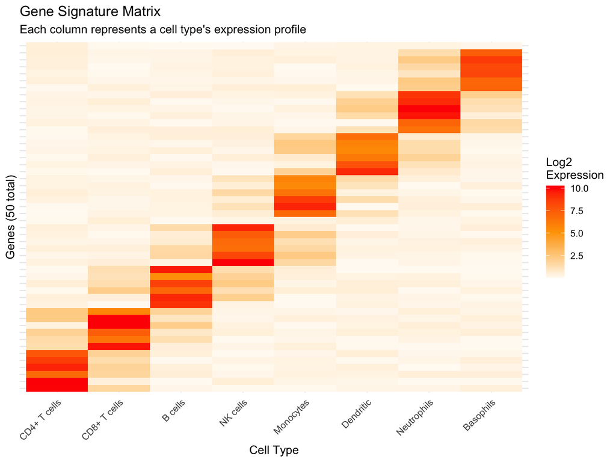

```r
# Conceptual demonstration with synthetic data
library(ggplot2)

# Create synthetic signature data
set.seed(42)
n_genes <- 50
n_types <- 8
type_names <- c("CD4+ T cells", "CD8+ T cells", "B cells", "NK cells",
                "Monocytes", "Dendritic", "Neutrophils", "Basophils")

# Generate signature with cell-type specific patterns
signature <- matrix(0, nrow = n_genes, ncol = n_types)
colnames(signature) <- type_names
rownames(signature) <- paste0("Gene", 1:n_genes)

# Each cell type gets specific marker genes
genes_per_type <- n_genes / n_types
for(i in 1:n_types) {
  start_idx <- (i-1) * genes_per_type + 1
  end_idx <- i * genes_per_type

  # High expression in target cell type
  signature[start_idx:end_idx, i] <- runif(genes_per_type, 5, 10)

  # Some spillover to related types
  if(i > 1) signature[start_idx:end_idx, i-1] <- runif(genes_per_type, 0, 2)
  if(i < n_types) signature[start_idx:end_idx, i+1] <- runif(genes_per_type, 0, 2)
}

# Add background noise
signature <- signature + matrix(runif(n_genes * n_types, 0, 0.5),
                                nrow = n_genes, ncol = n_types)

# Visualize with ggplot2
sig_long <- reshape2::melt(signature)
colnames(sig_long) <- c("Gene", "CellType", "Expression")

ggplot(sig_long, aes(x = CellType, y = Gene, fill = Expression)) +
  geom_tile() +
  scale_fill_gradient2(low = "white", mid = "orange", high = "red",
                       midpoint = 5, name = "Log2\nExpression") +
  theme_minimal() +
  theme(axis.text.x = element_text(angle = 45, hjust = 1),
        axis.text.y = element_blank(),
        axis.ticks.y = element_blank()) +
  labs(title = "Gene Signature Matrix",
       subtitle = "Each column represents a cell type's expression profile",
       x = "Cell Type", y = "Genes (50 total)")
```

### 3.1.1 Key Parameters

When using `signature_heatmap()`:

- `top`: Number of top genes to display per cell type
- `use_filter`: Whether to show noise-filtered signatures
- `scale`: Scaling method (“none”, “row”, “column”, “sphere”)
- `show_row_names`: Display gene names

## 3.2 Heatmap Interpretation

The signature heatmap reveals:

1. **Marker specificity**: Distinct bands indicate good markers
2. **Cell type similarity**: Similar columns suggest related cell types
3. **Signature quality**: Clean diagonal pattern indicates well-separated cell types

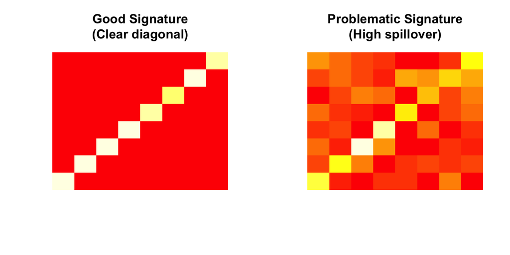

```r
# Create diagnostic plots
par(mfrow = c(1, 2))

# Good signature: clear diagonal
good_sig <- diag(8) * 8 + matrix(runif(64, 0, 1), 8, 8)
image(good_sig, main = "Good Signature\n(Clear diagonal)",
      col = heat.colors(20), axes = FALSE)

# Problematic signature: high spillover
bad_sig <- matrix(runif(64, 3, 6), 8, 8) + diag(8) * 3
image(bad_sig, main = "Problematic Signature\n(High spillover)",
      col = heat.colors(20), axes = FALSE)
```

```r
par(mfrow = c(1, 1))
```

# 4 Spillover Analysis

## 4.1 Spillover Heatmap

The spillover matrix quantifies how much signal from one cell type “spills over” into another during deconvolution.

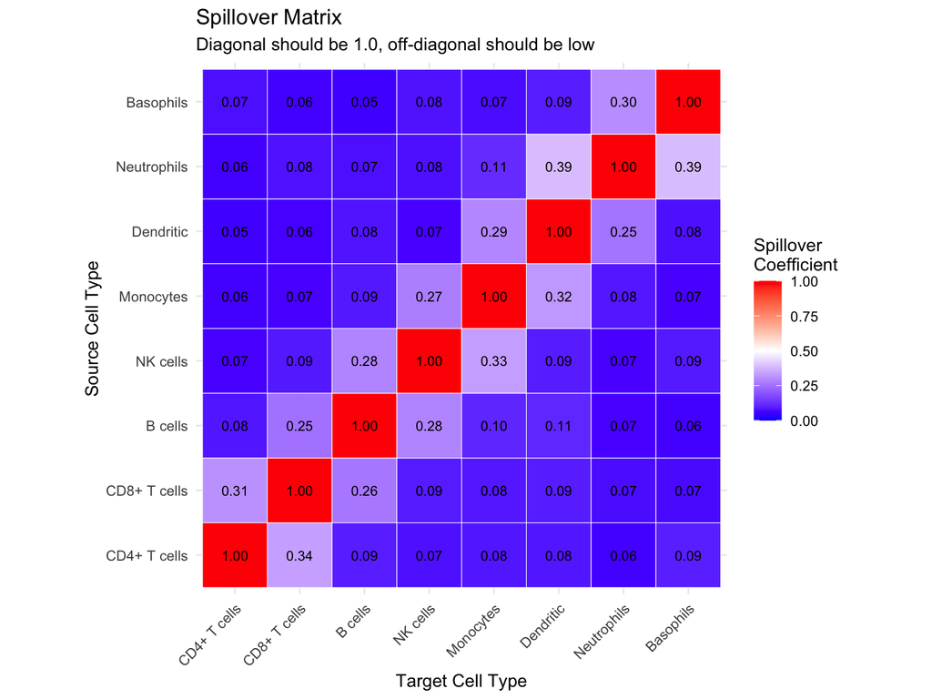

```r
# Calculate spillover matrix
calc_spillover <- function(S) {
  col_norms_sq <- colSums(S^2)
  spill <- t(S) %*% S
  sweep(spill, 2, col_norms_sq, "/")
}

spillover <- calc_spillover(signature)

# Visualize
spill_long <- reshape2::melt(spillover)
colnames(spill_long) <- c("From", "To", "Spillover")

ggplot(spill_long, aes(x = To, y = From, fill = Spillover)) +
  geom_tile(color = "white") +
  geom_text(aes(label = sprintf("%.2f", Spillover)), size = 3) +
  scale_fill_gradient2(low = "blue", mid = "white", high = "red",
                       midpoint = 0.5, limits = c(0, 1),
                       name = "Spillover\nCoefficient") +
  theme_minimal() +
  theme(axis.text.x = element_text(angle = 45, hjust = 1)) +
  labs(title = "Spillover Matrix",
       subtitle = "Diagonal should be 1.0, off-diagonal should be low",
       x = "Target Cell Type", y = "Source Cell Type") +
  coord_fixed()
```

## 4.2 Interpreting Spillover

| Spillover Value | Interpretation | Action |
| --- | --- | --- |
| 0.00 - 0.10 | Excellent separation | None needed |
| 0.10 - 0.25 | Acceptable | Monitor results |
| 0.25 - 0.50 | Moderate overlap | Consider merging or improving markers |
| > 0.50 | High overlap | Cell types may be indistinguishable |

# 5 Cosine Similarity

## 5.1 Understanding Cosine Similarity

Cosine similarity measures the angular relationship between cell type signatures.

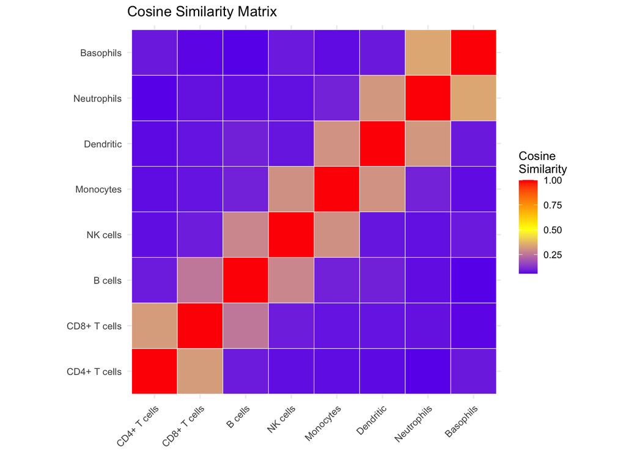

```r
# Calculate cosine similarity
calc_cosine <- function(S) {
  norms <- sqrt(colSums(S^2))
  sim <- t(S) %*% S / (norms %o% norms)
  return(sim)
}

cos_sim <- calc_cosine(signature)

# Convert to angles for interpretation
angles <- acos(pmin(cos_sim, 1)) * 180 / pi

# Visualize cosine similarity
cos_long <- reshape2::melt(cos_sim)
colnames(cos_long) <- c("TypeA", "TypeB", "Similarity")

p1 <- ggplot(cos_long, aes(x = TypeA, y = TypeB, fill = Similarity)) +
  geom_tile(color = "white") +
  scale_fill_gradient2(low = "blue", mid = "yellow", high = "red",
                       midpoint = 0.5, name = "Cosine\nSimilarity") +
  theme_minimal() +
  theme(axis.text.x = element_text(angle = 45, hjust = 1)) +
  labs(title = "Cosine Similarity Matrix",
       x = "", y = "") +
  coord_fixed()

print(p1)
```

## 5.2 Angular Distance Visualization

[figure not shown]

```r
# Visualize as angles
angle_long <- reshape2::melt(angles)
colnames(angle_long) <- c("TypeA", "TypeB", "Angle")

ggplot(angle_long, aes(x = TypeA, y = TypeB, fill = Angle)) +
  geom_tile(color = "white") +
  geom_text(aes(label = sprintf("%.0f°", Angle)), size = 2.5) +
  scale_fill_gradient2(low = "red", mid = "yellow", high = "green",
                       midpoint = 45, name = "Angular\nDistance (°)") +
  theme_minimal() +
  theme(axis.text.x = element_text(angle = 45, hjust = 1)) +
  labs(title = "Angular Distance Between Cell Types",
       subtitle = "90° = orthogonal (ideal), 0° = identical (problematic)",
       x = "", y = "") +
  coord_fixed()
```

# 6 Deconvolution Results

## 6.1 Scatter Plots with plot_set()

After deconvolution, compare predicted vs true proportions:

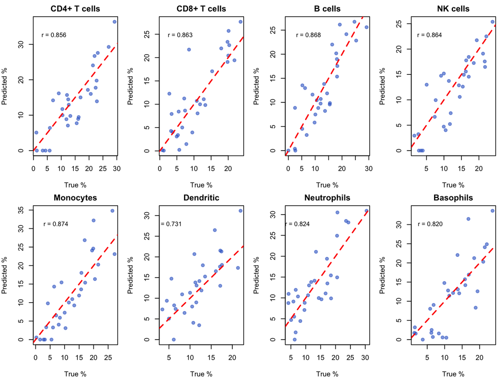

```r
# Simulate deconvolution results
set.seed(123)
n_samples <- 30

# True proportions (ground truth)
true_props <- matrix(runif(n_samples * n_types), nrow = n_samples, ncol = n_types)
true_props <- true_props / rowSums(true_props) * 100
colnames(true_props) <- type_names

# Predicted proportions (with some error)
pred_props <- true_props + matrix(rnorm(n_samples * n_types, 0, 5),
                                   nrow = n_samples, ncol = n_types)
pred_props[pred_props < 0] <- 0
pred_props <- pred_props / rowSums(pred_props) * 100
colnames(pred_props) <- type_names

# Create comparison plots
par(mfrow = c(2, 4), mar = c(4, 4, 2, 1))
for(i in 1:n_types) {
  plot(true_props[, i], pred_props[, i],
       xlab = "True %", ylab = "Predicted %",
       main = type_names[i],
       pch = 19, col = rgb(0.2, 0.4, 0.8, 0.6))
  abline(0, 1, col = "red", lty = 2, lwd = 2)

  # Add correlation
  r <- cor(true_props[, i], pred_props[, i])
  text(max(true_props[, i]) * 0.1, max(pred_props[, i]) * 0.9,
       sprintf("r = %.3f", r), adj = 0, cex = 0.9)
}
```

```r
par(mfrow = c(1, 1))
```

## 6.2 Performance Metrics

```r
# Calculate performance metrics
metrics <- data.frame(
  CellType = type_names,
  Pearson_R = sapply(1:n_types, function(i) cor(true_props[,i], pred_props[,i])),
  RMSE = sapply(1:n_types, function(i) sqrt(mean((true_props[,i] - pred_props[,i])^2))),
  MAE = sapply(1:n_types, function(i) mean(abs(true_props[,i] - pred_props[,i])))
)

# Format nicely
metrics$Pearson_R <- round(metrics$Pearson_R, 3)
metrics$RMSE <- round(metrics$RMSE, 2)
metrics$MAE <- round(metrics$MAE, 2)

knitr::kable(metrics, caption = "Deconvolution Performance Metrics")
```

Deconvolution Performance Metrics

| CellType | Pearson_R | RMSE | MAE |
| --- | --- | --- | --- |
| CD4+ T cells | 0.856 | 4.68 | 4.05 |
| CD8+ T cells | 0.863 | 4.25 | 3.20 |
| B cells | 0.868 | 3.86 | 3.19 |
| NK cells | 0.864 | 3.64 | 3.03 |
| Monocytes | 0.874 | 4.88 | 3.97 |
| Dendritic | 0.731 | 4.87 | 3.82 |
| Neutrophils | 0.824 | 4.61 | 3.91 |
| Basophils | 0.820 | 5.53 | 4.03 |

# 7 Stack Plots for Composition

Stack plots are ideal for visualizing sample composition:

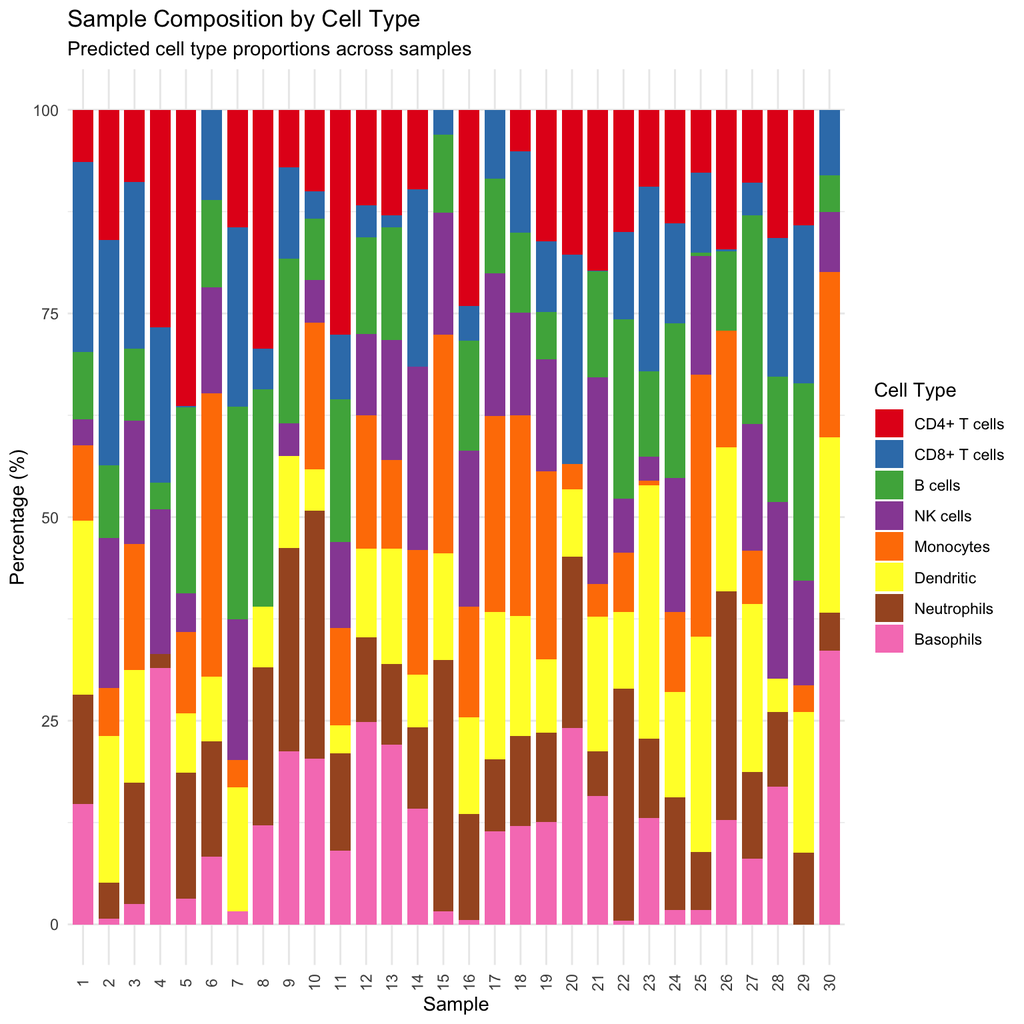

```r
# Prepare data for stacked bar chart
library(reshape2)

pred_long <- melt(pred_props)
colnames(pred_long) <- c("Sample", "CellType", "Percentage")
pred_long$Sample <- factor(pred_long$Sample, levels = 1:n_samples)

# Color palette
colors <- c("#E41A1C", "#377EB8", "#4DAF4A", "#984EA3",
            "#FF7F00", "#FFFF33", "#A65628", "#F781BF")

ggplot(pred_long, aes(x = Sample, y = Percentage, fill = CellType)) +
  geom_bar(stat = "identity", width = 0.8) +
  scale_fill_manual(values = colors, name = "Cell Type") +
  theme_minimal() +
  theme(axis.text.x = element_text(angle = 90, vjust = 0.5)) +
  labs(title = "Sample Composition by Cell Type",
       subtitle = "Predicted cell type proportions across samples",
       x = "Sample", y = "Percentage (%)")
```

# 8 Tuning Visualization

## 8.1 plot_tune() Results

When tuning deconvolution parameters:

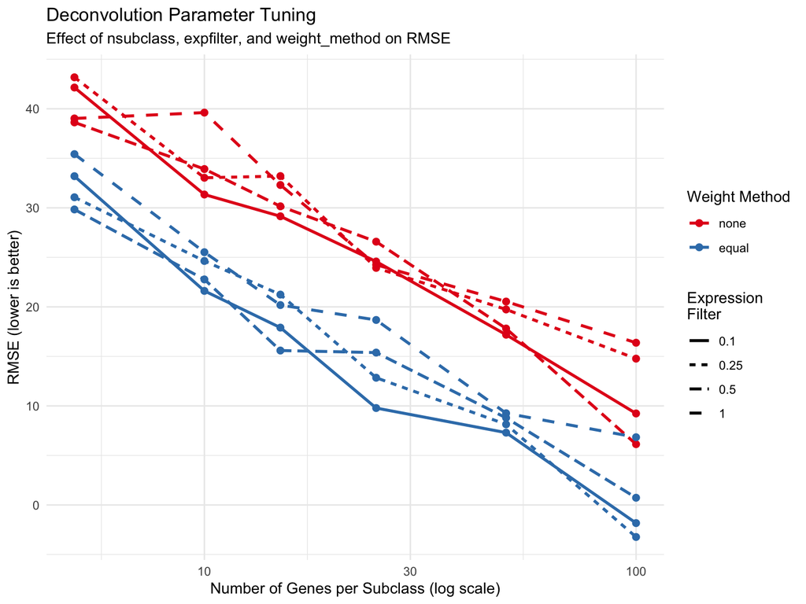

```r
# Simulate tuning results
tune_results <- expand.grid(
  nsubclass = c(5, 10, 15, 25, 50, 100),
  expfilter = c(0.1, 0.25, 0.5, 1.0),
  weight_method = c("none", "equal")
)

# Simulated RMSE (lower is better)
set.seed(42)
tune_results$RMSE <- 50 - 10 * log(tune_results$nsubclass) +
                      5 * tune_results$expfilter +
                      ifelse(tune_results$weight_method == "equal", -5, 5) +
                      rnorm(nrow(tune_results), 0, 2)

# Visualize
ggplot(tune_results, aes(x = nsubclass, y = RMSE,
                         color = weight_method, linetype = factor(expfilter))) +
  geom_line(linewidth = 1) +
  geom_point(size = 2) +
  scale_x_log10() +
  scale_color_manual(values = c("none" = "#E41A1C", "equal" = "#377EB8"),
                     name = "Weight Method") +
  scale_linetype_discrete(name = "Expression\nFilter") +
  theme_minimal() +
  labs(title = "Deconvolution Parameter Tuning",
       subtitle = "Effect of nsubclass, expfilter, and weight_method on RMSE",
       x = "Number of Genes per Subclass (log scale)",
       y = "RMSE (lower is better)")
```

# 9 Residual Diagnostics

## 9.1 Residual Analysis

Visualize regression diagnostics:

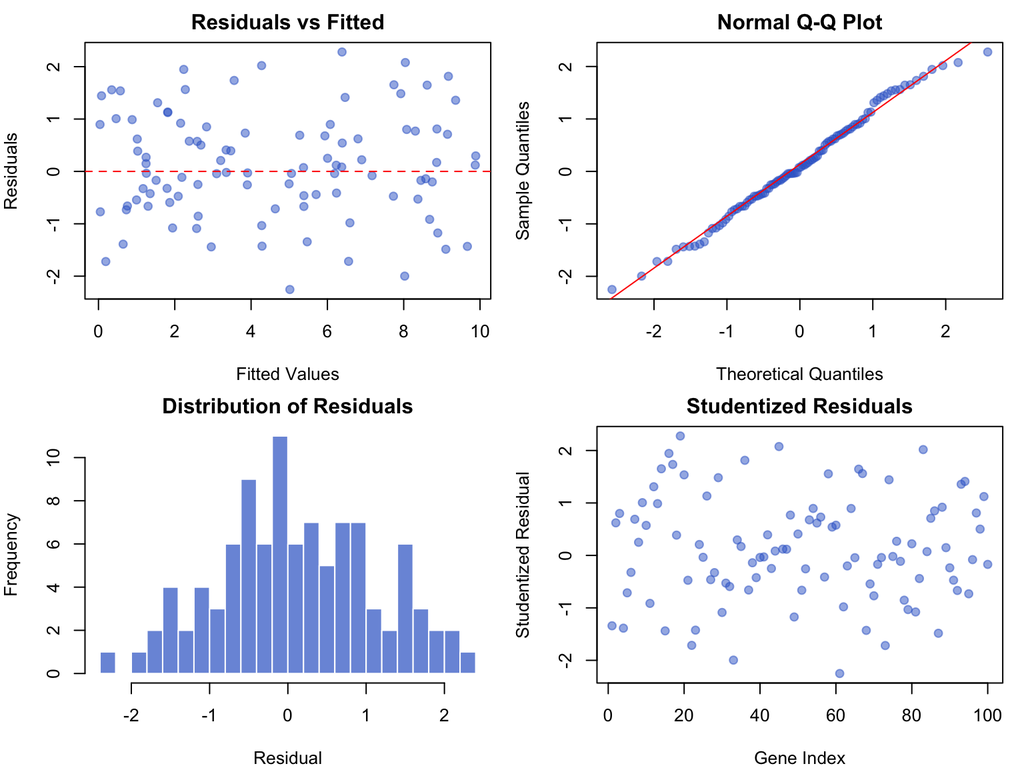

```r
# Simulate residuals
set.seed(456)
n_genes_sig <- 100
residuals <- rnorm(n_genes_sig, 0, 1)
fitted_values <- runif(n_genes_sig, 0, 10)
studentized <- residuals / sd(residuals)

par(mfrow = c(2, 2), mar = c(4, 4, 2, 1))

# Residuals vs Fitted
plot(fitted_values, residuals,
     xlab = "Fitted Values", ylab = "Residuals",
     main = "Residuals vs Fitted",
     pch = 19, col = rgb(0.2, 0.4, 0.8, 0.5))
abline(h = 0, col = "red", lty = 2)

# Q-Q Plot
qqnorm(studentized, main = "Normal Q-Q Plot",
       pch = 19, col = rgb(0.2, 0.4, 0.8, 0.5))
qqline(studentized, col = "red")

# Histogram of residuals
hist(residuals, breaks = 20, main = "Distribution of Residuals",
     xlab = "Residual", col = rgb(0.2, 0.4, 0.8, 0.7), border = "white")

# Studentized residuals
plot(1:n_genes_sig, studentized,
     xlab = "Gene Index", ylab = "Studentized Residual",
     main = "Studentized Residuals",
     pch = 19, col = ifelse(abs(studentized) > 3, "red", rgb(0.2, 0.4, 0.8, 0.5)))
abline(h = c(-3, 3), col = "red", lty = 2)
```

```r
par(mfrow = c(1, 1))
```

# 10 Best Practices

## 10.1 Visualization Checklist

When analyzing deconvolution results:

1. **Signature Quality**
   - Check signature heatmap for clear diagonal pattern
   - Verify spillover matrix has low off-diagonal values
   - Examine cosine similarity for highly similar cell types
2. **Deconvolution Results**
   - Compare scatter plots of predicted vs true (if available)
   - Check that proportions sum to 100%
   - Look for unexpected negative values or outliers
3. **Parameter Tuning**
   - Visualize tuning results across parameter ranges
   - Identify optimal parameter combinations
   - Validate with independent test data

## 10.2 Color Palette Recommendations

For consistent, publication-quality figures:

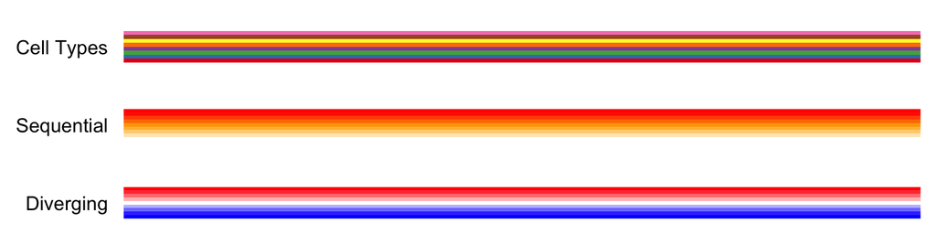

```r
# Recommended color palettes
palettes <- list(
  "Cell Types" = c("#E41A1C", "#377EB8", "#4DAF4A", "#984EA3",
                   "#FF7F00", "#FFFF33", "#A65628", "#F781BF"),
  "Sequential" = colorRampPalette(c("white", "orange", "red"))(9),
  "Diverging" = colorRampPalette(c("blue", "white", "red"))(9)
)

par(mfrow = c(3, 1), mar = c(1, 8, 2, 1))
for(name in names(palettes)) {
  image(matrix(1:length(palettes[[name]]), nrow = 1),
        col = palettes[[name]], axes = FALSE)
  mtext(name, side = 2, las = 1, line = 1)
}
```

```r
par(mfrow = c(1, 1))
```